# 1533: Data Mining and Decision Support Systems

## Session 1 Homework

Authors: Alexander Neulinger - 1025792, Michael Graf - 1152091, Filip Minic - 1053044

## Exercise 1

Manually collect data from the entire month of September. Use pd.concat() to merge all dataframes together into a single one. The easiest approach is to create a list at the very top to which you append the new dataframes and then insert this list into concat() function. Optional: Use a loop to automatically loop over the past couple of weeks.

We first begin the work of importing all of the modules that we used for the exercises so that we do not have to worry about that later.

```python
import asyncio # python3 async library
import calendar # calendar handling library
import concurrent.futures # concurrency library
import urllib.request # url and http processing library
from datetime import timedelta, date # handling date and date calulation
import numpy as np # linear algebra library
import pandas as pd # data frame handling library
import pylab as pl # plotting library
import matplotlib.pyplot as plt # plotting library
import statsmodels.api as sm # statistical model library
import scipy # scientific python library
import seaborn # plots library (violin plot)
from aiohttp import ClientSession # asynchronous http library
from bs4 import BeautifulSoup # XML parser, filter etc.
# inline python plots
% matplotlib inline
```

```python
# this class contains a IO async request
# can handle thousands of requests concurrently without breaking or using barely and CPU

class AsyncRequests:
    @staticmethod
    def html_get(urls):
        async def fetch(url, session):
            async with session.get(url) as response:
                return await response.read()

        async def cooler_get(u):
            tasks = []

            # Fetch all responses within one Client session,
            # keep connection alive for all requests.
            async with ClientSession() as session:
                for i in u:
                    task = asyncio.ensure_future(fetch(i, session))
                    tasks.append(task)

                responses = await asyncio.gather(*tasks)
                # you now have all response bodies in this variable
                return responses

        loop = asyncio.get_event_loop()
        future = asyncio.ensure_future(cooler_get(urls))
        responses = loop.run_until_complete(future)
        return responses
```

To ecapsulate the data and functions as an object we decided to create a class that we can use for getting data from a month.

```python
class Month:
    def __init__(self, year: int, month: int):
        self.NUM_DAYS = calendar.monthrange(year, month)
        self.FIRST_DAY = date(year, month, 1)
        self.LAST_DAY = date(year, month, self.NUM_DAYS[1])
        self.PERIODS = []
        for i in range(self.FIRST_DAY.day, self.LAST_DAY.day, 7):
            if not (i + 6 > self.LAST_DAY.day):
                self.PERIODS.append(date(year, month, i))

        self.PERIODS.append(date(year, month, self.LAST_DAY.day - self.LAST_DAY.day % 7))

    @staticmethod
    def df_transform(results):
        soups = [BeautifulSoup(result, 'html.parser') for result in results]
        tables = [soup.find_all('table', class_='list hours responsive') for soup in soups]
        tables = [pd.read_html(str(table[1]), header=0, encoding='utf8')[0] for table in tables]
        tables = [table.drop(['Unnamed: 0', 'Unnamed: 1'], axis=1) for table in tables]
        working_dataframe = pd.concat([i for i in tables], axis=1)
        return working_dataframe

    @staticmethod
    def get_week(dates):
        dates = [i + timedelta(days=6) for i in dates]
        urls = ['https://www.epexspot.com/en/market-data/dayaheadauction/auction-table/'
                + str(date) + '/de' for date in dates]
        results = AsyncRequests.html_get(urls)
        return results

    def get_prices(self):
        dates = [i for i in self.PERIODS]
        df = Month.df_transform(Month.get_week(dates))

        index = pd.date_range(start=str(self.FIRST_DAY)
                                    + '-00:00', end=str(self.PERIODS[-1]
                                                        + timedelta(days=7))
                                                    + '-23:00', freq='h')

        prices = df[::2].transpose().stack()
        prices.index = index
        removal = -24 * (self.LAST_DAY.day % 7 + 3) #TODO figure out why this works
        prices = prices[0:removal]

        volumes = df[1::2].transpose().stack()
        volumes.index = index
        volumes = volumes[0:removal]

        df = pd.concat([prices, volumes], axis=1)
        df.columns = ["price", "volume"]
        return df
```

In the next 3 lines we define the month that we want to get, we store the result of the get_prices() function which basically returns a reference to a dataframe object that we can use for our analysis.

```python
m = Month(2017, 9)
data_frame = m.get_prices()
print(data_frame.head())
print()
print("The number of data points in one dimension is " + str(len(data_frame[::24])))
```

```
                     price   volume
2017-09-01 00:00:00  33.09  21195.0
2017-09-01 01:00:00  31.07  21672.6
2017-09-01 02:00:00  29.89  21394.2
2017-09-01 03:00:00  29.64  21187.1
2017-09-01 04:00:00  29.65  20109.8

The number of data points in one dimension is 30
```

The data looks fine the number of data points divided by 24 is 30 which is the number of days in the month of September, for better overview we did not display every single one. Now we proceed to Exercise 2.

## Exercise 2

Create a sample of peak prices (9:00 to 20:00) and base prices (24-hour mean) and summarize the data with a simple descriptive statistics containing min, max, mean, std deviation, as well as both quartiles. Then create a histogram of the distribution of both figures in one plot.

We use the code featured below to get the data from the dataframe for peak as well as mean values between 9h and 20h.

```
Text(0,0.5,'Price in EUR')
```

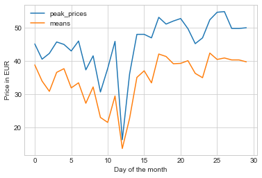

```python
# initialize needed arrays and pull_date variable
peak_prices = []
means = []
dates = []
pull_date = date(2017, 9, 1)

# compute necessary metrics and store them into the arrays
for i in range(m.LAST_DAY.day):
    dates.append(pull_date)
    begin = str(pull_date) + ' 09:00:00'
    end = str(pull_date) + ' 20:00:00'
    peak_prices.append(data_frame.loc[begin:end]['price'].max())
    begin = str(pull_date) + ' 00:00:00'
    end = str(pull_date) + ' 23:00:00'
    means.append(data_frame.loc[begin:end]['price'].mean())
    pull_date += timedelta(days=1)

dates = pd.Series(dates, name='date')
peak_prices = pd.Series(peak_prices, name='peak_prices')
means = pd.Series(means, name="means")

peaks_means = pd.concat([dates, peak_prices, means], axis=1)

ax = peaks_means.plot()
ax.set_xlabel('Day of the month')
ax.set_ylabel('Price in EUR')
```

we draw a simple plot of the peak prices and mean prices on a single graph so we may compare them. Below we look at the metrics that are required in the exercise and draw up histograms of both the prices and the volumes.

```python
data_frame.describe()
```

|  | price | volume |
| --- | --- | --- |
| count | 720.000000 | 720.000000 |
| mean | 34.504486 | 25092.820833 |
| std | 10.490800 | 4870.125306 |
| min | -11.040000 | 16378.800000 |
| 25% | 30.295000 | 21097.550000 |
| 50% | 34.900000 | 24317.050000 |
| 75% | 41.115000 | 28697.200000 |
| max | 57.000000 | 40724.600000 |

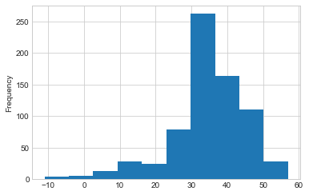

```python
data_frame['price'].plot.hist()
```

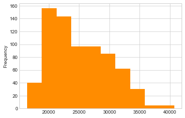

```python
data_frame['volume'].plot.hist(color='DarkOrange')
```

## Exercise 3

Group the data by hour and plot the price distribution in one graph.

We group the data and show it in the following two blocks of code.

```python
times = pd.to_datetime(data_frame.index)
data_frame.groupby(times.hour).price.sum().head()
```

```
0    833.84
1    774.92
2    751.96
3    724.62
4    737.76
Name: price, dtype: float64
```

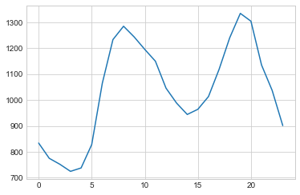

```python
data_frame.groupby(times.hour).price.sum().plot()
```

Below we display the data in violin plots in order to have a more compact overview of both density and the data distribution, in our view this is beneficial as we not only see the desciptive statistics such as where the median is, quartiles the range between quartiles but also the probability densities.

[figure not shown]

```python
seaborn.set_style("whitegrid")  # appearance for the violin plot
seaborn.violinplot(x=peaks_means['peak_price'])
```

[figure not shown]

```python
seaborn.violinplot(x=means)
```

## Exercise 4

Measure and plot the relationship between price and volume. What is the causal relationship between the two figures?

We look at two correlation results below, spearman as well as pearson.

```python
scipy.stats.pearsonr(data_frame['price'], data_frame['volume'])
```

```
(-0.17470461505975798, 2.4054232679745716e-06)
```

According to the Pearson correlation if anything there is a negative one, which is probably due to the lack of more data.

```python
scipy.stats.spearmanr(data_frame['price'], data_frame['volume'])
```

```
SpearmanrResult(correlation=0.0041742853889510829, pvalue=0.91097112126562652)
```

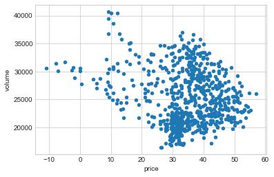

```python
ax = data_frame.plot(kind='scatter', x='price', y='volume')
```

In the scatterplot it seems like the data might be correlated but there are some unusual outliers and the data is spread out in some parts too much to conclude anything, but there are some clusters of pricing and volume.

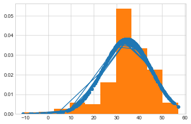

```python
fit = scipy.stats.norm.pdf(data_frame['price'], np.mean(data_frame['price']), np.std(data_frame['price']))
pl.plot(data_frame['price'], fit, '-o')
pl.hist(data_frame['price'], normed=True)
pl.show()
```

```python
ax = data_frame['2017-09-01':'2017-09-30']['price'].plot()
ax.set_xlabel("Hours")
ax.set_xlabel("Price")
```

[output not shown]

[output not shown]

[output not shown]

[output not shown]

```python
p = data_frame['price'].as_matrix()
v = data_frame['volume'].as_matrix()
```

[output not shown]

[output not shown]

[output not shown]

```python
model = sm.OLS(p, v).fit()
# predictions = model.predict(X) # make the predictions by the model

# Print out the statistics
model.summary()
```

OLS Regression Results

| Dep. Variable: | y | R-squared: | 0.864 |
| --- | --- | --- | --- |
| Model: | OLS | Adj. R-squared: | 0.864 |
| Method: | Least Squares | F-statistic: | 4577. |
| Date: | Tue, 17 Oct 2017 | Prob (F-statistic): | 5.65e-314 |
| Time: | 00:17:13 | Log-Likelihood: | -2884.2 |
| No. Observations: | 720 | AIC: | 5770. |
| Df Residuals: | 719 | BIC: | 5775. |
| Df Model: | 1 |  |  |
| Covariance Type: | nonrobust |  |  |

|  | coef | std err | t | P>\|t\| | [0.025 | 0.975] |
| --- | --- | --- | --- | --- | --- | --- |
| x1 | 0.0013 | 1.94e-05 | 67.650 | 0.000 | 0.001 | 0.001 |

| Omnibus: | 149.096 | Durbin-Watson: | 0.121 |
| --- | --- | --- | --- |
| Prob(Omnibus): | 0.000 | Jarque-Bera (JB): | 281.145 |
| Skew: | -1.201 | Prob(JB): | 8.92e-62 |
| Kurtosis: | 4.899 | Cond. No. | 1.00 |

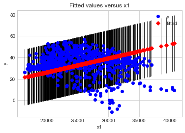

```python
fig, ax = plt.subplots()
ax.set_xlabel("Price")
ax.set_xlabel("Volume")
fig = sm.graphics.plot_fit(model, 0, ax=ax)
```

## Exercise 5

Create a time series of daily averages.

Thanks to some pandas magic we can do this in one line since we have the means already all we need is to get the index for the days and voila.

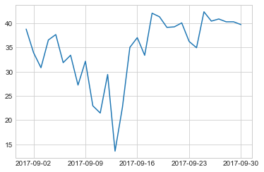

```python
plt.plot(data_frame.index[::24],peaks_means['means'])
```